# credit

주제: 이진분류기법(3)

목차

1. 이진분류기법이란?
2. 데이터 확인
3. 탐색적 데이터 분석(EDA)
4. 데이터 전처리
5. 다양한 모델들을 통한 분류(예측) -> Logistic Regression
6. 다양한 모델들을 통한 분류(예측) -> Random Forest
7. 환경데이터로의 활용방안

# 1. 이진분류기법이란?

-> 분류는 어떠한 변수에 영향을 받는 결과를 연속적이지 않은 값들로 나눌 때 사용합니다. 특히나, 이진 분류는 구분하고자 하는 결과값이 상호 배타적인 변수들 중 하나를 출력하는 분류 작업 유형입니다.

# 2.데이터 확인 및 전처리

- 데이터 설명

  -> 홈 크레딧그룹에서 과거 대출 신청 데이터를 사용하여 신청자가 대출금을 상환할 수 있는지 여부를 예측하기위해 제공하는 데이터입니다. 홈 크레딧은 신용 이력이 부족하거나 존재하지 않아 대출을 받기 어려운 소외 계층에게 안전한 차입 경험을 제공함으로써 금융 거래의 폭을 넓히는 것을 도와주는 플랫폼입니다. 홈 크레딧은 고객의 상환 능력을 예측하기위해 통신사와 거래정보를 포함한 다양한 대체 데이터를 이용하고자 합니다.

  -> 분류: 타겟 라벨은 이진 변수 0(대출금을 제 때 상환함), 1(대여금 상환에 어려움이 있음)
  - 데이터 소스 7가지

  -> application_train/application_test : 홈 크레딧에 있는 대출 신청 데이터. 모든 대출 이력은 SK_ID_CURR을 통해 개별 내역 식별이 가능합니다.

  -> bureau : 다른 금융기관으로부터 대출 신정자의 이전 신용에 관한 데이터.

  -> bureau_balance : bureau 데이터에서의 이전 신용에 관한 월별 데이터. 각 행은 이전 신용의 한 달이며, 이전 신용의 한달마다 여러 행을 가질 수 있습니다.

  -> previous_application : application 데이터에 대출이 있는 대출 신청자의 이전에 홈 크레딧 대출 신청 데이터. 모든 대출 이력은 SK_ID_PREV를 통해 개별 내역 식별이 가능합니다.

  -> pop_cash_balance : 대출 신청자가 월별로 현금대출한 내역의 데이터입니다. 각 행은 전매점 또는 현금대출의 한 달이며, 이전 대출 한 건은 많은 행을 가질 수 있습니다.

  -> credit_card_balance : 대출 신청자가 홈 크레딧에 가지고 있던 이전에 신용 카드에 대한 월별 데이터입니다. 각 행은 신용카드 잔액의 한 달이며, 하나의 신용카드에는 여러 행이 있을 수 있습니다.

  -> installments_payment : 홈 크레딧의 이전 대출에 대한 지급 내역. 결제가 있을 때마다 한 행씩 있습니다.

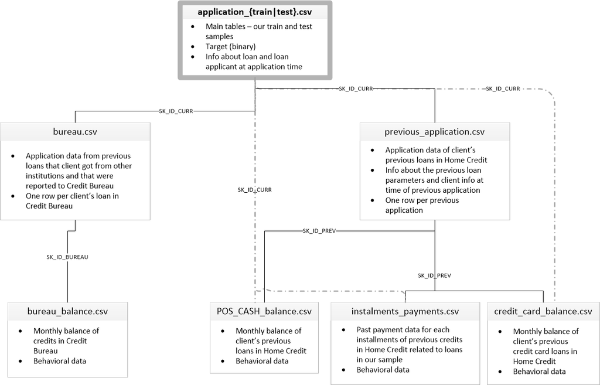

```python
# 라이브러리 불러오기

import numpy as np
import pandas as pd

from sklearn.preprocessing import LabelEncoder

import os

import warnings
warnings.filterwarnings('ignore')

import matplotlib.pyplot as plt
import seaborn as sns
```

- 데이터 확인

```python
app_train = pd.read_csv('C:/Users/USER/Desktop/python 연습/data/home-credit-default-risk/application_train.csv')
print('Training data shape: ', app_train.shape)
app_train.head()
```

```
Training data shape:  (307511, 122)
```

|  | SK_ID_CURR | TARGET | NAME_CONTRACT_TYPE | CODE_GENDER | FLAG_OWN_CAR | FLAG_OWN_REALTY | CNT_CHILDREN | AMT_INCOME_TOTAL | AMT_CREDIT | AMT_ANNUITY | ... | FLAG_DOCUMENT_18 | FLAG_DOCUMENT_19 | FLAG_DOCUMENT_20 | FLAG_DOCUMENT_21 | AMT_REQ_CREDIT_BUREAU_HOUR | AMT_REQ_CREDIT_BUREAU_DAY | AMT_REQ_CREDIT_BUREAU_WEEK | AMT_REQ_CREDIT_BUREAU_MON | AMT_REQ_CREDIT_BUREAU_QRT | AMT_REQ_CREDIT_BUREAU_YEAR |
| --- | --- | --- | --- | --- | --- | --- | --- | --- | --- | --- | --- | --- | --- | --- | --- | --- | --- | --- | --- | --- | --- |
| 0 | 100002 | 1 | Cash loans | M | N | Y | 0 | 202500.0 | 406597.5 | 24700.5 | ... | 0 | 0 | 0 | 0 | 0.0 | 0.0 | 0.0 | 0.0 | 0.0 | 1.0 |
| 1 | 100003 | 0 | Cash loans | F | N | N | 0 | 270000.0 | 1293502.5 | 35698.5 | ... | 0 | 0 | 0 | 0 | 0.0 | 0.0 | 0.0 | 0.0 | 0.0 | 0.0 |
| 2 | 100004 | 0 | Revolving loans | M | Y | Y | 0 | 67500.0 | 135000.0 | 6750.0 | ... | 0 | 0 | 0 | 0 | 0.0 | 0.0 | 0.0 | 0.0 | 0.0 | 0.0 |
| 3 | 100006 | 0 | Cash loans | F | N | Y | 0 | 135000.0 | 312682.5 | 29686.5 | ... | 0 | 0 | 0 | 0 | NaN | NaN | NaN | NaN | NaN | NaN |
| 4 | 100007 | 0 | Cash loans | M | N | Y | 0 | 121500.0 | 513000.0 | 21865.5 | ... | 0 | 0 | 0 | 0 | 0.0 | 0.0 | 0.0 | 0.0 | 0.0 | 0.0 |

5 rows × 122 columns

```python
app_test = pd.read_csv('C:/Users/USER/Desktop/python 연습/data/home-credit-default-risk/application_test.csv')
print('Testing data shape: ', app_test.shape)
app_test.head()
```

```
Testing data shape:  (48744, 121)
```

|  | SK_ID_CURR | NAME_CONTRACT_TYPE | CODE_GENDER | FLAG_OWN_CAR | FLAG_OWN_REALTY | CNT_CHILDREN | AMT_INCOME_TOTAL | AMT_CREDIT | AMT_ANNUITY | AMT_GOODS_PRICE | ... | FLAG_DOCUMENT_18 | FLAG_DOCUMENT_19 | FLAG_DOCUMENT_20 | FLAG_DOCUMENT_21 | AMT_REQ_CREDIT_BUREAU_HOUR | AMT_REQ_CREDIT_BUREAU_DAY | AMT_REQ_CREDIT_BUREAU_WEEK | AMT_REQ_CREDIT_BUREAU_MON | AMT_REQ_CREDIT_BUREAU_QRT | AMT_REQ_CREDIT_BUREAU_YEAR |
| --- | --- | --- | --- | --- | --- | --- | --- | --- | --- | --- | --- | --- | --- | --- | --- | --- | --- | --- | --- | --- | --- |
| 0 | 100001 | Cash loans | F | N | Y | 0 | 135000.0 | 568800.0 | 20560.5 | 450000.0 | ... | 0 | 0 | 0 | 0 | 0.0 | 0.0 | 0.0 | 0.0 | 0.0 | 0.0 |
| 1 | 100005 | Cash loans | M | N | Y | 0 | 99000.0 | 222768.0 | 17370.0 | 180000.0 | ... | 0 | 0 | 0 | 0 | 0.0 | 0.0 | 0.0 | 0.0 | 0.0 | 3.0 |
| 2 | 100013 | Cash loans | M | Y | Y | 0 | 202500.0 | 663264.0 | 69777.0 | 630000.0 | ... | 0 | 0 | 0 | 0 | 0.0 | 0.0 | 0.0 | 0.0 | 1.0 | 4.0 |
| 3 | 100028 | Cash loans | F | N | Y | 2 | 315000.0 | 1575000.0 | 49018.5 | 1575000.0 | ... | 0 | 0 | 0 | 0 | 0.0 | 0.0 | 0.0 | 0.0 | 0.0 | 3.0 |
| 4 | 100038 | Cash loans | M | Y | N | 1 | 180000.0 | 625500.0 | 32067.0 | 625500.0 | ... | 0 | 0 | 0 | 0 | NaN | NaN | NaN | NaN | NaN | NaN |

5 rows × 121 columns

# 3. 탐색적 데이터 분석(EDA)

- target 변수의 분포 확인

```python
app_train['TARGET'].value_counts()
```

```
0    282686
1     24825
Name: TARGET, dtype: int64
```

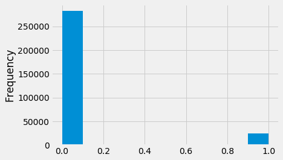

```python
app_train['TARGET'].astype(int).plot.hist();
```

위 정보로부터,타겟 변수에서 불균형 문제가 있다는 것을 확인할 수 있습니다. 즉, 갚지 않은 대출보다 제때 갚은 대출이 훨씬 많다는 의미이기도 합니다. 좀 더 정교한 모델링에 들어가면, 데이터의 불균형한 문제를 반영하기 위해 클래스에 가중치를 부여함으로써 그것들을 대체하려합니다.

- 결측치 확인

```python
def missing_values_table(df):
        # Total missing values
        mis_val = df.isnull().sum()

        # Percentage of missing values
        mis_val_percent = 100 * df.isnull().sum() / len(df)

        # Make a table with the results
        mis_val_table = pd.concat([mis_val, mis_val_percent], axis=1)

        # Rename the columns
        mis_val_table_ren_columns = mis_val_table.rename(
        columns = {0 : 'Missing Values', 1 : '% of Total Values'})

        # Sort the table by percentage of missing descending
        mis_val_table_ren_columns = mis_val_table_ren_columns[
            mis_val_table_ren_columns.iloc[:,1] != 0].sort_values(
        '% of Total Values', ascending=False).round(1)

        # Print some summary information
        print ("Your selected dataframe has " + str(df.shape[1]) + " columns.\n"
            "There are " + str(mis_val_table_ren_columns.shape[0]) +
              " columns that have missing values.")

        # Return the dataframe with missing information
        return mis_val_table_ren_columns
```

```python
missing_values = missing_values_table(app_train)
missing_values.head(20)
```

```
Your selected dataframe has 122 columns.
There are 67 columns that have missing values.
```

|  | Missing Values | % of Total Values |
| --- | --- | --- |
| COMMONAREA_MEDI | 214865 | 69.9 |
| COMMONAREA_AVG | 214865 | 69.9 |
| COMMONAREA_MODE | 214865 | 69.9 |
| NONLIVINGAPARTMENTS_MEDI | 213514 | 69.4 |
| NONLIVINGAPARTMENTS_MODE | 213514 | 69.4 |
| NONLIVINGAPARTMENTS_AVG | 213514 | 69.4 |
| FONDKAPREMONT_MODE | 210295 | 68.4 |
| LIVINGAPARTMENTS_MODE | 210199 | 68.4 |
| LIVINGAPARTMENTS_MEDI | 210199 | 68.4 |
| LIVINGAPARTMENTS_AVG | 210199 | 68.4 |
| FLOORSMIN_MODE | 208642 | 67.8 |
| FLOORSMIN_MEDI | 208642 | 67.8 |
| FLOORSMIN_AVG | 208642 | 67.8 |
| YEARS_BUILD_MODE | 204488 | 66.5 |
| YEARS_BUILD_MEDI | 204488 | 66.5 |
| YEARS_BUILD_AVG | 204488 | 66.5 |
| OWN_CAR_AGE | 202929 | 66.0 |
| LANDAREA_AVG | 182590 | 59.4 |
| LANDAREA_MEDI | 182590 | 59.4 |
| LANDAREA_MODE | 182590 | 59.4 |

모델링을 하게 될 때면, 이렇게 누락된 값들을 채워야합니다. 이후 작업에서는 귀속 없이 누락된 값을 처리할 수 있는 XGBoost 등의 모델을 사용할 예정입니다. 또 다른 옵션은 결측값의 비율이 높은 변수를 삭제하는 것이지만, 이 변수가 모델링에 도움이 될지 미리 알 수는 없습니다. 따라서 모든 변수를 유지할 예정입니다.

- 데이터 유형 확인

  int64와 float64는 수치형 변수(이산형 혹은 연속형 변수), object는 문자열을 포함하는 범주형 변수입니다.

```python
app_train.dtypes.value_counts()
```

```
float64    65
int64      41
object     16
dtype: int64
```

-> 16개의 범주형 변수의 경우 각 변수에 몇 개의 항목이 있는지 확인하겠습니다.

```python
app_train.select_dtypes('object').apply(pd.Series.nunique, axis = 0)
```

```
NAME_CONTRACT_TYPE             2
CODE_GENDER                    3
FLAG_OWN_CAR                   2
FLAG_OWN_REALTY                2
NAME_TYPE_SUITE                7
NAME_INCOME_TYPE               8
NAME_EDUCATION_TYPE            5
NAME_FAMILY_STATUS             6
NAME_HOUSING_TYPE              6
OCCUPATION_TYPE               18
WEEKDAY_APPR_PROCESS_START     7
ORGANIZATION_TYPE             58
FONDKAPREMONT_MODE             4
HOUSETYPE_MODE                 3
WALLSMATERIAL_MODE             7
EMERGENCYSTATE_MODE            2
dtype: int64
```

- 범주형 변수 인코딩 작업 본 작업에 앞서, 범주형 변수를 전처리 해줄 필요가 있습니다. 머신러닝 모델링을 하는데 있어 범주형 변수를 다룰 수는 없습니다(LightGBM과 같은 일부 모델 제외). 따라서 이 범주형 변수를 모델에 적용하기 전에 숫자로 인코딩하는 방법을 알아야합니다. 이 과정을 수행하는 방법은 크게 두가지가 있습니다.
- 라벨 인코딩 : 정수를 가진 범주형 변수에 각 고유 범주를 할당합니다. 새 열은 생성되지 않습니다.

  예시)

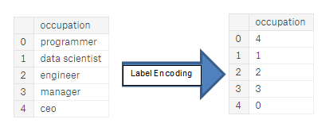

- One-hot 인코딩(더미변수 생성) : 범주형 변수의 각 고유 범주에 대해 새 열을 생성합니다. 각 관측치는 해당 카테고리에 대해 컬럼에 1개, 다른 모든 새로운 컬럼에 0개씩 받는다.

  예시)

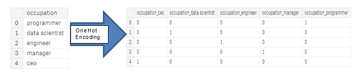

-> 라벨 인코딩의 문제는 카테고리에 임의의 순서를 부여한다는 것입니다. 각 범주에 할당 된 값은 랜덤이며 범주의 고유한 측면을 반영하지 않습니다. 정수의 실제 배정은 임의적입니다. 따라서 라벨 인코딩을 수행할 때 모델은 변수의 상대적인 값을 사용하여 우리가 원하는 것이 아닌 가중치를 할당할 수 있습니다. 범주형 변수에 대해 두 개의 고유 측정치만 있다면, 라벨 인코딩은 괜찮지만, 두 개 이상의 고유 범주에 대해서는 1-핫 인코딩이 안전한 옵션입니다. one-hot 인코딩의 유일한 단점은 측정값을 많이 가진 범주형 변수들로 인해 많은 변수가 생성되어 모델링에 어려움을 겪을 수 있습니다. 그래서 PCA 또는 기타 차원 감소 방법에 따라 단열 인코딩을 수행하여 차수의 수를 줄일 수 있습니다. 해당 보고서에서는 카테고리 2개만 있는 범주형 변수에 대해서는 라벨 인코딩을, 카테고리 2개 이상의 범주형 변수에 대해서는 One-hot 인코딩을 사용합니다. 이 과정은 분석이 더 진행된 경우 변경해야 할 수도 있지만, 현재로서는 이러한 과정으로 진행할 예정입니다.

- 라벨 인코딩과 One-Hot 인코딩

```python
le = LabelEncoder()
le_count = 0

for col in app_train:
    if app_train[col].dtype == 'object':
        if len(list(app_train[col].unique())) <= 2:
            le.fit(app_train[col])
            app_train[col] = le.transform(app_train[col])
            app_test[col] = le.transform(app_test[col])
            le_count += 1

print('%d columns were label encoded.' % le_count)
```

```
3 columns were label encoded.
```

```python
app_train = pd.get_dummies(app_train)
app_test = pd.get_dummies(app_test)

print('Training Features shape: ', app_train.shape)
print('Testing Features shape: ', app_test.shape)
```

```
Training Features shape:  (307511, 243)
Testing Features shape:  (48744, 239)
```

- trainning data set과 test data set 정렬

```python
train_labels = app_train['TARGET']

# Align the training and testing data, keep only columns present in both dataframes
app_train, app_test = app_train.align(app_test, join = 'inner', axis = 1)

# Add the target back in
app_train['TARGET'] = train_labels

print('Training Features shape: ', app_train.shape)
print('Testing Features shape: ', app_test.shape)
```

```
Training Features shape:  (307511, 240)
Testing Features shape:  (48744, 239)
```

- 데이터 내 이상징후 확인

  EDA를 수행할 때 항상 경계해야하는 문제는 데이터 내의 이상징후입니다. 이는 잘못 입력된 숫자, 측정 상의 요류 또는 유효하지만 극단적인 측정값이 발생할 때 입니다. 이상 징후를 정량적으로 확인하는 방법은 각 변수의 통계를 살펴 보는 것입니다.

-> DAYS_BIRTH(나이) 변수의 숫자는 현재 대출 신청에 비해 기록되기 때문에 음수입니다. 이러한 통계를 제대로 보려면 -1로 이상을 일으켜 1년 내에 일 수로 나누어 주어야 나이를 확인할 수 있습니다.

```python
(app_train['DAYS_BIRTH'] / -365).describe()
```

```
count    307511.000000
mean         43.936973
std          11.956133
min          20.517808
25%          34.008219
50%          43.150685
75%          53.923288
max          69.120548
Name: DAYS_BIRTH, dtype: float64
```

```python
app_train['DAYS_EMPLOYED'].describe()
```

```
count    307511.000000
mean      63815.045904
std      141275.766519
min      -17912.000000
25%       -2760.000000
50%       -1213.000000
75%        -289.000000
max      365243.000000
Name: DAYS_EMPLOYED, dtype: float64
```

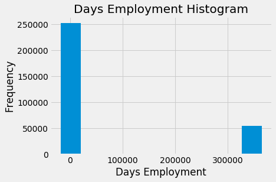

```python
app_train['DAYS_EMPLOYED'].plot.hist(title = 'Days Employment Histogram');
plt.xlabel('Days Employment');
```

-> DAYS_EMPLOYED(취업일) 변수의 숫자는 적절하게 설정되는 것 같진 않습니다.

```python
anom = app_train[app_train['DAYS_EMPLOYED'] == 365243]
non_anom = app_train[app_train['DAYS_EMPLOYED'] != 365243]
print('The non-anomalies default on %0.2f%% of loans' % (100 * non_anom['TARGET'].mean()))
print('The anomalies default on %0.2f%% of loans' % (100 * anom['TARGET'].mean()))
print('There are %d anomalous days of employment' %len(anom))
```

```
The non-anomalies default on 8.66% of loans
The anomalies default on 5.40% of loans
There are 55374 anomalous days of employment
```

-> 이상 징후를 처리하는 것은 정해진 규칙없이 정확한 상황에 따라 달라집니다. 가장 좋은 방법 중 하나는 이상 징후를 누락된 값으로 설정한 다음 모델링 전에 채우도록 하는 것입니다. 이 경우, 모든 이상징후가 정확히 같은 값을 가지므로, 모든 대출 내역이 공통적인 것을 가르킬 경우에 대비하여 동일한 값으로 채워넣고자 합니다. 이상적인 값들은 어느정도 중요성이 있는 것 같으므로 실제로 이러한 값들을 채웠는지 모델링 전에 확인하고자 합니다. 이상적인 값을 숫자가 아닌 np.nan값으로 채운 다음, 그 값이 변칙적인지 여부를 나타내는 새로운 칼럼을 만들 것입니다.

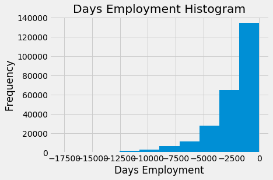

```python
app_train['DAYS_EMPLOYED_ANOM'] = app_train['DAYS_EMPLOYED'] == 365243

app_train['DAYS_EMPLOYED'].replace({365243:np.nan}, inplace = True)

app_train['DAYS_EMPLOYED'].plot.hist(title = 'Days Employment Histogram');
plt.xlabel('Days Employment');
```

-> 분포를 확인하였을때, 모델이 이러한 값이 원래 비정상적이었음을 알려주기 위해 새로운 열을 만들었습니다.매우 중요한 참고 사항으로, trainning data에 대해 수행하는 모든 작업은 테스트 데이터에도 수행해야 합니다. 새 열을 만들고 기존 열을 테스트 데이터에 np.nan으로 채워주겠습니다.

```python
app_test['DAYS_EMPLOYED_ANOM'] = app_test["DAYS_EMPLOYED"] == 365243
app_test["DAYS_EMPLOYED"].replace({365243: np.nan}, inplace = True)

print('There are %d anomalies in the test data out of %d entries' % (app_test["DAYS_EMPLOYED_ANOM"].sum(), len(app_test)))
```

```
There are 9274 anomalies in the test data out of 48744 entries
```

- 각 변수의 상관관계 파악

데이터를 이해하는 방법중에 하는 각 변수간의 상관관계를 찾는 것입니다. 상관 계수는 변수 간의 '관련성'을 나타내는 가장 좋은 방법은 아니지만, 데이터 내에서 가능한 관계에 대한 아이디어를 제공합니다. 상관계수의 절댓값에 대한 일반적인 해석은 다음과 같습니다.

- 0.00-0.19 : "매우 약한 상관관계"
- 0.20-0.39 : "약한 상관관계"
- 0.40-0.59 : "상관관계가 있다"
- 0.60-0.79 : "강한 상관관계"
- 0.80-1.0 : "매우 강한 상관관계"

```python
correlations = app_train.corr()['TARGET'].sort_values()

print('Most Positive Correlations: \n', correlations.tail(15))
print('\nMost Negative Correlations: \n ', correlations.head(15))
```

```
Most Positive Correlations:
 OCCUPATION_TYPE_Laborers                             0.043019
FLAG_DOCUMENT_3                                      0.044346
REG_CITY_NOT_LIVE_CITY                               0.044395
FLAG_EMP_PHONE                                       0.045982
NAME_EDUCATION_TYPE_Secondary / secondary special    0.049824
REG_CITY_NOT_WORK_CITY                               0.050994
DAYS_ID_PUBLISH                                      0.051457
CODE_GENDER_M                                        0.054713
DAYS_LAST_PHONE_CHANGE                               0.055218
NAME_INCOME_TYPE_Working                             0.057481
REGION_RATING_CLIENT                                 0.058899
REGION_RATING_CLIENT_W_CITY                          0.060893
DAYS_EMPLOYED                                        0.074958
DAYS_BIRTH                                           0.078239
TARGET                                               1.000000
Name: TARGET, dtype: float64

Most Negative Correlations:
  EXT_SOURCE_3                           -0.178919
EXT_SOURCE_2                           -0.160472
EXT_SOURCE_1                           -0.155317
NAME_EDUCATION_TYPE_Higher education   -0.056593
CODE_GENDER_F                          -0.054704
NAME_INCOME_TYPE_Pensioner             -0.046209
DAYS_EMPLOYED_ANOM                     -0.045987
ORGANIZATION_TYPE_XNA                  -0.045987
FLOORSMAX_AVG                          -0.044003
FLOORSMAX_MEDI                         -0.043768
FLOORSMAX_MODE                         -0.043226
EMERGENCYSTATE_MODE_No                 -0.042201
HOUSETYPE_MODE_block of flats          -0.040594
AMT_GOODS_PRICE                        -0.039645
REGION_POPULATION_RELATIVE             -0.037227
Name: TARGET, dtype: float64
```

- 나이가 상환에 미치는 영향(TARGET과 DAYS_BIRTH 간의 상관관계)

```python
app_train['DAYS_BIRTH'] = abs(app_train['DAYS_BIRTH'])
app_train['DAYS_BIRTH'].corr(app_train['TARGET'])
```

```
-0.07823930830982737
```

-> 고객이 나이가 들수록 대출금을 제때 갚는 경향이 있다는 것을 의미하는 타겟변수와 음의 상관관계를 띄고 있습니다.

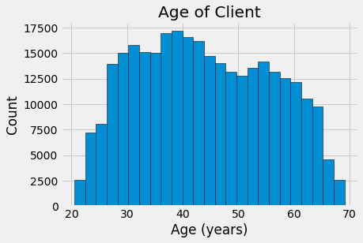

```python
plt.style.use('fivethirtyeight')

plt.hist(app_train['DAYS_BIRTH'] / 365, edgecolor = 'k', bins = 25)
plt.title('Age of Client'); plt.xlabel('Age (years)'); plt.ylabel('Count');
```

-> 고객의 나이대를 히스토그램을 통해 시각화해서 보았을 때, 비교적 고르게 분포되어있는 것을 확인할 수가 있었습니다.

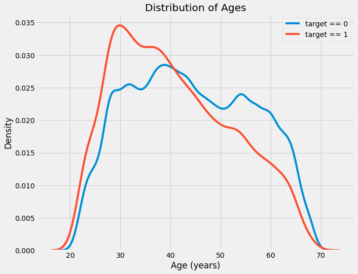

```python
plt.figure(figsize = (10, 8))

sns.kdeplot(app_train.loc[app_train['TARGET'] == 0, 'DAYS_BIRTH'] / 365,
           label = 'target == 0')

sns.kdeplot(app_train.loc[app_train['TARGET'] == 1, 'DAYS_BIRTH'] / 365,
           label = 'target == 1')

plt.xlabel('Age (years)'); plt.ylabel('Density'); plt.title('Distribution of Ages');
```

-> 다음은 타깃변수(0과 1일때)에 따른 나잇대의 분포를 나타내는 커널밀도곡선입니다. target == 1일 때의 곡선에서는 비교적 젊은 나이대에 분포가 많이 되어있는 것을 확인할 수가 있습니다. 이는 유의한 상관관계는 아니지만, 이 변수는 대상에 영향을 미치기 때문에 머신러닝 모델에서 유용할 가능성이 높습니다. 이 관계를 또 다른 방식으로 보자면, 연령대별 대출금 상환 실패의 평균입니다.

```python
age_data = app_train[['TARGET', 'DAYS_BIRTH']]
age_data['YEARS_BIRTH'] = age_data['DAYS_BIRTH'] / 365

age_data['YEARS_BINNED'] = pd.cut(age_data['YEARS_BIRTH'], bins = np.linspace (20, 70, num = 11))
age_data.head(10)
```

|  | TARGET | DAYS_BIRTH | YEARS_BIRTH | YEARS_BINNED |
| --- | --- | --- | --- | --- |
| 0 | 1 | 9461 | 25.920548 | (25.0, 30.0] |
| 1 | 0 | 16765 | 45.931507 | (45.0, 50.0] |
| 2 | 0 | 19046 | 52.180822 | (50.0, 55.0] |
| 3 | 0 | 19005 | 52.068493 | (50.0, 55.0] |
| 4 | 0 | 19932 | 54.608219 | (50.0, 55.0] |
| 5 | 0 | 16941 | 46.413699 | (45.0, 50.0] |
| 6 | 0 | 13778 | 37.747945 | (35.0, 40.0] |
| 7 | 0 | 18850 | 51.643836 | (50.0, 55.0] |
| 8 | 0 | 20099 | 55.065753 | (55.0, 60.0] |
| 9 | 0 | 14469 | 39.641096 | (35.0, 40.0] |

```python
age_groups = age_data.groupby('YEARS_BINNED').mean()
age_groups
```

| YEARS_BINNED | TARGET | DAYS_BIRTH | YEARS_BIRTH |
| --- | --- | --- | --- |
| (20.0, 25.0] | 0.123036 | 8532.795625 | 23.377522 |
| (25.0, 30.0] | 0.111436 | 10155.219250 | 27.822518 |
| (30.0, 35.0] | 0.102814 | 11854.848377 | 32.479037 |
| (35.0, 40.0] | 0.089414 | 13707.908253 | 37.555913 |
| (40.0, 45.0] | 0.078491 | 15497.661233 | 42.459346 |
| (45.0, 50.0] | 0.074171 | 17323.900441 | 47.462741 |
| (50.0, 55.0] | 0.066968 | 19196.494791 | 52.593136 |
| (55.0, 60.0] | 0.055314 | 20984.262742 | 57.491131 |
| (60.0, 65.0] | 0.052737 | 22780.547460 | 62.412459 |
| (65.0, 70.0] | 0.037270 | 24292.614340 | 66.555108 |

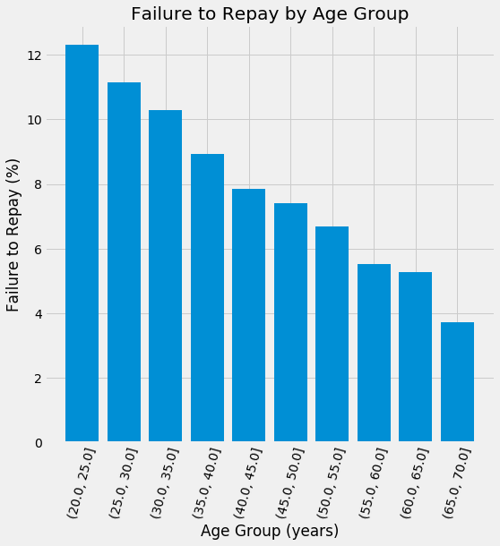

```python
plt.figure(figsize = (8,8))

plt.bar(age_groups.index.astype(str), 100 * age_groups['TARGET'])

plt.xticks(rotation = 75); plt.xlabel('Age Group (years)'); plt.ylabel('Failure to Repay (%)')
plt.title('Failure to Repay by Age Group');
```

- 외부 자료 타겟 변수와 음의 상관관계가 가장 강한 3가지 변수는 EXT_SOURCE_1, EXT_SOURCE_2, EXT_SOURCE_3입니다. 설명자료에 따르면, 이러한 변수는 "외부 데이터 자료에서 얻은 정규화된 점수"를 나타냅니다. 이것이 정확히 무엇을 의미하는지는 잘 모르겠지만, 아마도 수많은 자료의 출처를 이용하여 이루어진 누적된 종류의 신용등급일 것입니다.

```python
ext_data = app_train[['TARGET', 'EXT_SOURCE_1', 'EXT_SOURCE_2', 'EXT_SOURCE_3', 'DAYS_BIRTH']]
ext_data_corrs = ext_data.corr()
ext_data_corrs
```

|  | TARGET | EXT_SOURCE_1 | EXT_SOURCE_2 | EXT_SOURCE_3 | DAYS_BIRTH |
| --- | --- | --- | --- | --- | --- |
| TARGET | 1.000000 | -0.155317 | -0.160472 | -0.178919 | -0.078239 |
| EXT_SOURCE_1 | -0.155317 | 1.000000 | 0.213982 | 0.186846 | 0.600610 |
| EXT_SOURCE_2 | -0.160472 | 0.213982 | 1.000000 | 0.109167 | 0.091996 |
| EXT_SOURCE_3 | -0.178919 | 0.186846 | 0.109167 | 1.000000 | 0.205478 |
| DAYS_BIRTH | -0.078239 | 0.600610 | 0.091996 | 0.205478 | 1.000000 |

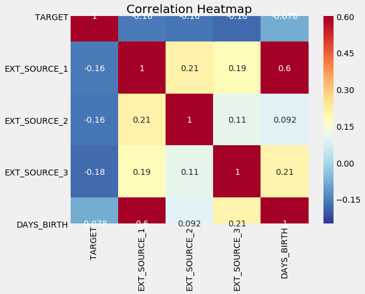

```python
plt.figure(figsize = (8, 6))

sns.heatmap(ext_data_corrs, cmap = plt.cm.RdYlBu_r, vmin = -0.25, annot = True, vmax = 0.6)
plt.title('Correlation Heatmap');
```

-> EXT_SOURCE의 세 가지 특징 모두 대상과 부정적인 상관관계를 가지며, 이는 EXT_SOURCE의 가치가 증가함에 따라 고객이 대출금을 상환할 가능성이 더 높다는 것을 나타냅니다. 또한 DAYS_BIRTH가 EXT_SOURCE_1과 양의 상관관계라는 것을 알 수 있으며, 계수의 요인 중 하나가 고객의 연령일 수 있습니다.

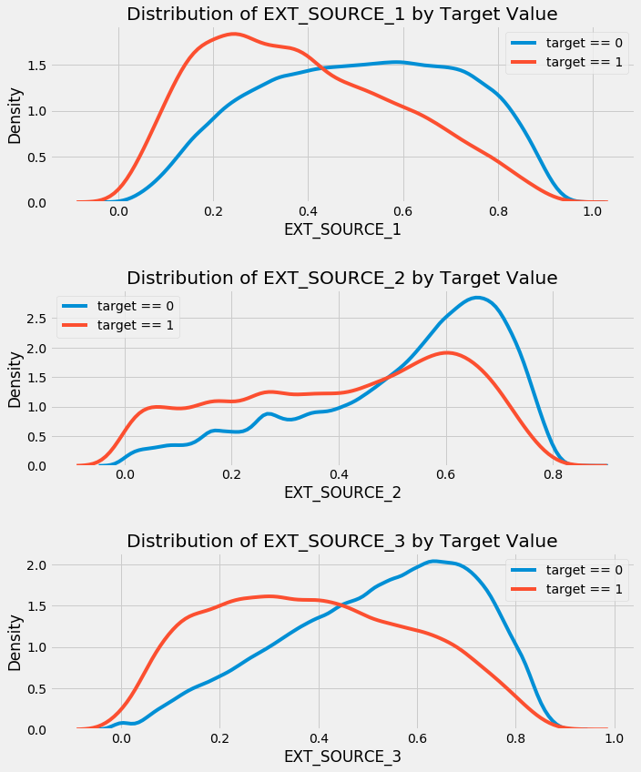

```python
plt.figure(figsize = (10,12))

for i, source in enumerate(['EXT_SOURCE_1', 'EXT_SOURCE_2', 'EXT_SOURCE_3']):
    plt.subplot(3, 1, i+1)
    sns.kdeplot(app_train.loc[app_train['TARGET'] == 0, source], label = 'target == 0')
    sns.kdeplot(app_train.loc[app_train['TARGET'] == 1, source], label = 'target == 1')

    plt.title('Distribution of %s by Target Value' % source)
    plt.xlabel('%s' % source); plt.ylabel('Density');

plt.tight_layout(h_pad = 2.5)
```

-> EXT_SOURCE_3는 대상 값 사이의 가장 큰 차이를 보여줍니다. 이 변수가 대출 신청자가 대출금을 상환할 가능성과 어느정도 관련이 있다는 것을 분명히 알 수 있습니다. 그 관계는 그리 강하지 않습니다.(사실, 모두 매우 약한 것으로 간주되지만, 이러한 변수는 여전히 기계학습 모델에 있어서 신청자가 대출금을 제 때 갚을 것인지 여부를 예측하는데 유용할 것 입니다.)

- 변수 간 특징 파악(EXT_SOURCE and Age)

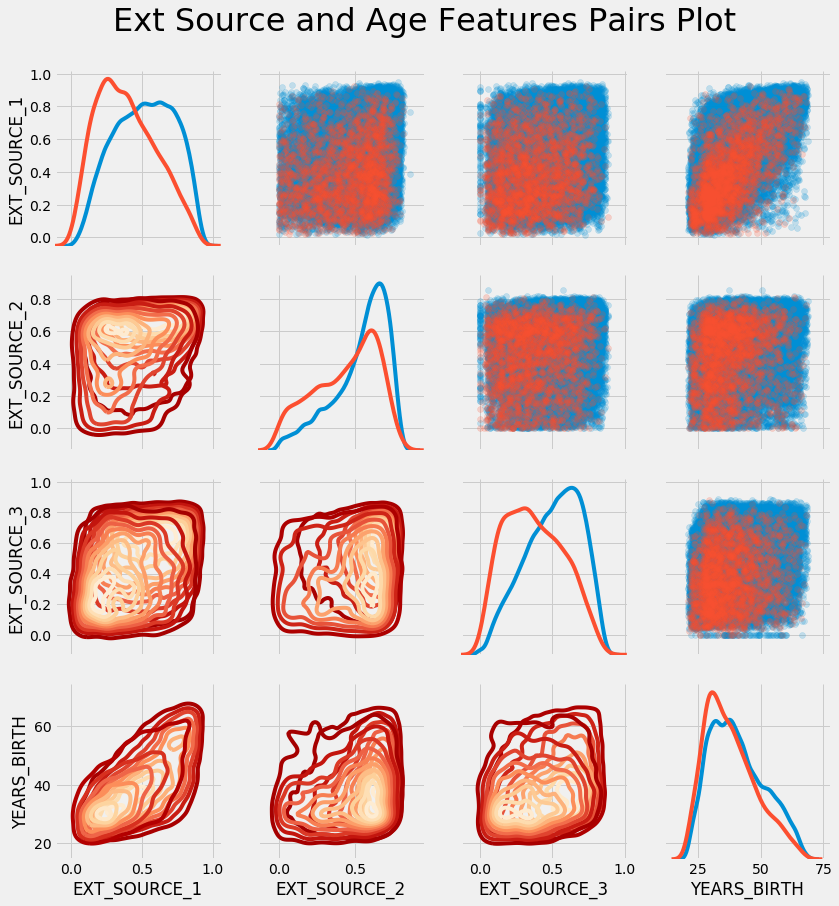

```python
plot_data = ext_data.drop(columns = ['DAYS_BIRTH']).copy()

plot_data['YEARS_BIRTH'] = age_data['YEARS_BIRTH']

plot_data = plot_data.dropna().loc[:100000, :]

def corr_func(x, y, **kwargs):
    r = np.corrcoef(x, y)[0][1]
    ax = plt.gca()
    ax.annotate("r = {:.2f}".format(r),
               xy = (.2, .8), xycoords = ax.transAxes,
                size = 20)

grid = sns.PairGrid(data = plot_data, size = 3, diag_sharey = False,
                    hue = 'TARGET',
                    vars = [x for x in list(plot_data.columns) if x != 'TARGET'])

grid.map_upper(plt.scatter, alpha = 0.2)

grid.map_diag(sns.kdeplot)

grid.map_lower(sns.kdeplot, cmap = plt.cm.OrRd_r);

plt.suptitle('Ext Source and Age Features Pairs Plot', size = 32, y = 1.05);
```

-> 위 그래프에서 빨간색은 대출 미상환을 나타내고 파란색은 대출상환을 나타냅니다. 자료 안에서 서로 다른 관계를 볼 수 있습니다. EXT_SOURCE_1과 YEARS_BIRTH 사이에는 중간 정도의 양의 선형관계가 있는 것으로 나타나 이 변수가 고객의 나이를 고려할 수 있음을 나타냅니다.

# 4. 데이터 전처리

- 파생변수 만들기

  -> 여러 개별 변수의 조합인 파생변수는 변수 간의 상호작용을 파악하여 모델링을 하는데 있어 좀 더 유의미한 변수를 찾아내기 위한 작업이니다. 즉, 두 변수 자체로는 target변수에 큰 영향을 미치지 않을 수 있지만, 그것들을 하나의 파생변수로 결합하면 target변수와의 관계를 좀 더 유의미하게 파악할 수 있습니다. 경우에 따라서는, 해당 분야의 지식이 가미가 되는 경우에는 좀 더 유의미한 파생변수를 만들게 되어 모델링의 타당성을 좀 더 높이는데 기여할 수 있을 것입니다.
- EXT_SOURCE 변수와 DAYS_BIRTH변수를 사용하여 파생변수를 만들고자 합니다.

```python
poly_features = app_train[['EXT_SOURCE_1', 'EXT_SOURCE_2', 'EXT_SOURCE_3', 'DAYS_BIRTH', 'TARGET']]
poly_features_test = app_test[['EXT_SOURCE_1', 'EXT_SOURCE_2', 'EXT_SOURCE_3', 'DAYS_BIRTH']]

from sklearn.preprocessing import Imputer
imputer = Imputer(strategy = 'median')

poly_target = poly_features['TARGET']

poly_features = poly_features.drop(columns = ['TARGET'])

poly_features = imputer.fit_transform(poly_features)
poly_features_test = imputer.transform(poly_features_test)

from sklearn.preprocessing import PolynomialFeatures

poly_transformer = PolynomialFeatures(degree = 3)
```

```python
poly_transformer.fit(poly_features)

poly_features = poly_transformer.transform(poly_features)
poly_features_test = poly_transformer.transform(poly_features_test)
print('Polynomial Features shape: ', poly_features.shape)
```

```
Polynomial Features shape:  (307511, 35)
```

-> 위 작업을 통해서 새로운 변수들을 만들 수 있었습니다. 총 35개의 변수를 새로 얻게 되었는데 이들 중 어떤 것이 target변수와 연관되어 있는지 알아보겠습니다.

```python
poly_transformer.get_feature_names(input_features = ['EXT_SOURCE_1', 'EXT_SOURCE_2', 'EXT_SOURCE_3', 'DAYS_BIRTH'])[:15]
```

```
['1',
 'EXT_SOURCE_1',
 'EXT_SOURCE_2',
 'EXT_SOURCE_3',
 'DAYS_BIRTH',
 'EXT_SOURCE_1^2',
 'EXT_SOURCE_1 EXT_SOURCE_2',
 'EXT_SOURCE_1 EXT_SOURCE_3',
 'EXT_SOURCE_1 DAYS_BIRTH',
 'EXT_SOURCE_2^2',
 'EXT_SOURCE_2 EXT_SOURCE_3',
 'EXT_SOURCE_2 DAYS_BIRTH',
 'EXT_SOURCE_3^2',
 'EXT_SOURCE_3 DAYS_BIRTH',
 'DAYS_BIRTH^2']
```

```python
poly_features = pd.DataFrame(poly_features,
                            columns = poly_transformer.get_feature_names(['EXT_SOURCE_1', 'EXT_SOURCE_2', 'EXT_SOURCE_3', 'DAYS_BIRTH']))

poly_features['TARGET'] = poly_target

poly_corrs = poly_features.corr()['TARGET'].sort_values()

print(poly_corrs.head(10))
print(poly_corrs.tail(5))
```

```
EXT_SOURCE_2 EXT_SOURCE_3                -0.193939
EXT_SOURCE_1 EXT_SOURCE_2 EXT_SOURCE_3   -0.189605
EXT_SOURCE_2 EXT_SOURCE_3 DAYS_BIRTH     -0.181283
EXT_SOURCE_2^2 EXT_SOURCE_3              -0.176428
EXT_SOURCE_2 EXT_SOURCE_3^2              -0.172282
EXT_SOURCE_1 EXT_SOURCE_2                -0.166625
EXT_SOURCE_1 EXT_SOURCE_3                -0.164065
EXT_SOURCE_2                             -0.160295
EXT_SOURCE_2 DAYS_BIRTH                  -0.156873
EXT_SOURCE_1 EXT_SOURCE_2^2              -0.156867
Name: TARGET, dtype: float64
DAYS_BIRTH     -0.078239
DAYS_BIRTH^2   -0.076672
DAYS_BIRTH^3   -0.074273
TARGET          1.000000
1                    NaN
Name: TARGET, dtype: float64
```

-> 상관관계를 파악해본 결과 새로운 변수들 중 몇 개는 원래 변수보다 target변수와 더 큰 상관관계를 갖고 있었습니다. 보통 머신러닝 모델링을 진행할 때, 이러한 변수들이 실제로 모델링에 도움이 되는지 여부를 결정하기 위해 이러한 변수들을 가지고 모델링을 시도해볼 수 있습니다. 그래서, 이러한 변수들을 trainng set과 test set의 사본에 추가한 다음 그 변수들이 있는 경우와 없는 경우의 모델을 평가할 것입니다.

```python
poly_features_test = pd.DataFrame(poly_features_test,
                                 columns = poly_transformer.get_feature_names(['EXT_SOURCE_1', 'EXT_SOURCE_2', 'EXT_SOURCE_3', 'DAYS_BIRTH']))

poly_features['SK_ID_CURR'] = app_train['SK_ID_CURR']
app_train_poly = app_train.merge(poly_features, on = 'SK_ID_CURR', how = 'left')

poly_features_test['SK_ID_CURR'] = app_test['SK_ID_CURR']
app_test_poly = app_test.merge(poly_features_test, on = 'SK_ID_CURR', how = 'left')

app_train_poly, app_test_poly = app_train_poly.align(app_test_poly, join = 'inner', axis = 1)

print('Training data with polynomial features shape: ', app_train_poly.shape)
print('Testing data with polynomial features shape: ', app_test_poly.shape)
```

```
Training data with polynomial features shape:  (307511, 275)
Testing data with polynomial features shape:  (48744, 275)
```

- 도메인 지식과 관련된 변수

  -> CREDIT_INCOME_PERCENT : 고객의 소득 대비 신용 금액의 비율 -> ANNUITY_INCOME_PERCENT : 고객의 소득 대비 대출 연간 비율 -> CREDIT_TERM: 지급기간(매월 지급해야 하는 금액) -> DAYS_EMPLOYED_PERCENT: 고객의 연령을 기준으로 한 일간 비율

```python
app_train_domain = app_train.copy()
app_test_domain = app_test.copy()

app_train_domain['CREDIT_INCOME_PERCENT'] = app_train_domain['AMT_CREDIT'] / app_train_domain['AMT_INCOME_TOTAL']
app_train_domain['ANNUITY_INCOME_PERCENT'] = app_train_domain['AMT_ANNUITY'] / app_train_domain['AMT_INCOME_TOTAL']
app_train_domain['CREDIT_TERM'] = app_train_domain['AMT_ANNUITY'] / app_train_domain['AMT_CREDIT']
app_train_domain['DAYS_EMPLOYED_PERCENT'] = app_train_domain['DAYS_EMPLOYED'] / app_train_domain['DAYS_BIRTH']
```

```python
app_test_domain['CREDIT_INCOME_PERCENT'] = app_test_domain['AMT_CREDIT'] / app_test_domain['AMT_INCOME_TOTAL']
app_test_domain['ANNUITY_INCOME_PERCENT'] = app_test_domain['AMT_ANNUITY'] / app_test_domain['AMT_INCOME_TOTAL']
app_test_domain['CREDIT_TERM'] = app_test_domain['AMT_ANNUITY'] / app_test_domain['AMT_CREDIT']
app_test_domain['DAYS_EMPLOYED_PERCENT'] = app_test_domain['DAYS_EMPLOYED'] / app_test_domain['DAYS_BIRTH']
```

-> 위에서 불러온 도메인 지식 변수를 그래프로써 시각적으로 탐구해보려합니다.

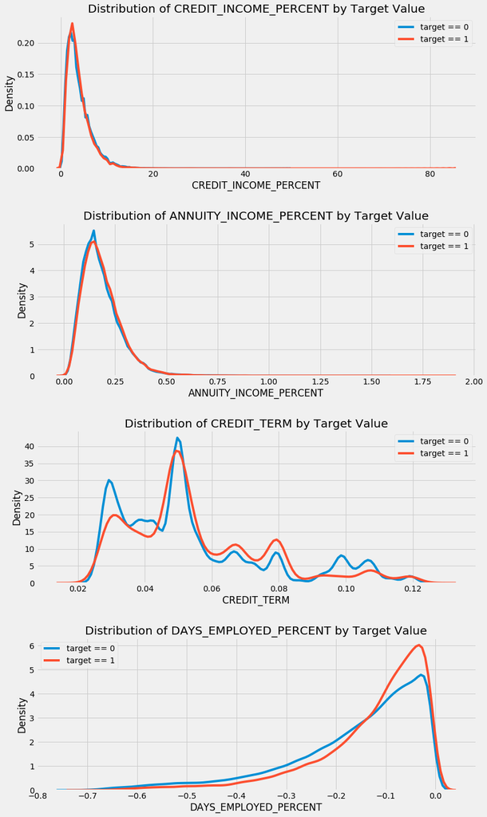

```python
plt.figure(figsize = (12,20))

for i, feature in enumerate(['CREDIT_INCOME_PERCENT', 'ANNUITY_INCOME_PERCENT', 'CREDIT_TERM', 'DAYS_EMPLOYED_PERCENT']):
    plt.subplot(4, 1, i+1)
    sns.kdeplot(app_train_domain.loc[app_train_domain['TARGET'] == 0, feature], label = 'target == 0')
    sns.kdeplot(app_train_domain.loc[app_train_domain['TARGET'] == 1, feature], label = 'target == 1')
    plt.title('Distribution of %s by Target Value' % feature)
    plt.xlabel('%s' % feature); plt.ylabel('Density');

plt.tight_layout(h_pad = 2.5)
```

-> 위에 그래프들을 통해서는 새로운 변수들이 확실히 유의미한 정보라고 보기에는 다소 어려움이 따라보입니다, 그래서 실제 모델링 작업을 진행하면 보완할 필요가 있어보입니다.

# 5. 다양한 모델들을 통한 분류(예측) -> Logistic Regression

- Logistic Regression

  -> Logistic Regression은 독립 변수들의 선형 결합을 이용하여 사건의 발생 가능성을 예측하는데 사용되는 통계 기법입니다. 목적은 일반적인 회귀 분석의 목표와 동일하게 종속변수와 독립변수간의 관계를 구체적인 함수로 나타내어 향후 예측 모델에 사용하는 것입니다. 이는 독립변수의 선형 결합으로 종속 변수를 설명한다는 관점에서는 선형 회귀 분석과 유사합니다. 하지만 Logistic Regression은 선형회귀분석과는 다르게 종속 변수가 범주형 데이터를 대상으로 하여 입력 데이터가 주어졌을 때 해당 데이터의 결과가 특정 분류로 나뉘기 때문에 일종의 분류(classification)기법으로도 볼 수 있습니다. -> 흔히 Logistic Regression은 종속변수가 이항형 문제를 지칭할 때 사용됩니다. 이외에, 두 개 이상의 범주를 가지는 문제가 대상인 경우엔 multinomial logistic regression 또는 polytomous logistic regression라 하고 복수의 범주이면서 순서가 존재하면 ordinal logistic regression 이라고 한다.(출처 : 위키백과)

```python
from sklearn.preprocessing import MinMaxScaler, Imputer

# Drop the target from the training data

if 'TARGET' in app_train:
    train = app_train.drop(columns = ['TARGET'])
else:
    train = app_train.copy()

# Feature names
features = list(train.columns)

# Copy of the testing data
test = app_test.copy()

# Median imputation of missing values
imputer = Imputer(strategy = 'median')

# Scale each feature to 0-1
scaler = MinMaxScaler(feature_range = (0, 1))

# Fit on the training data
imputer.fit(train)

# Transform both training and testing data
train = imputer.transform(train)
test = imputer.transform(app_test)

# Repeat with the scaler
scaler.fit(train)
train = scaler.transform(train)
test = scaler.transform(test)

print('Training data shape: ', train.shape)
print('Testing data shape: ', test.shape)
```

```
Training data shape:  (307511, 240)
Testing data shape:  (48744, 240)
```

-> 위 작업은 기본 모델에서 과적합(Overfiting)의 양을 제어하는 minmax정규화를 진행하였습니다. 이는 기존 Logistic Regression보다 더 나은 결과를 얻기위함입니다.

```python
from sklearn.linear_model import LogisticRegression

# Make the model with the specified regularization parameter

log_reg = LogisticRegression(C = 0.0001)

# Train on the training data

log_reg.fit(train, train_labels)
```

```
LogisticRegression(C=0.0001, class_weight=None, dual=False, fit_intercept=True,
                   intercept_scaling=1, l1_ratio=None, max_iter=100,
                   multi_class='warn', n_jobs=None, penalty='l2',
                   random_state=None, solver='warn', tol=0.0001, verbose=0,
                   warm_start=False)
```

```python
# Make predictions
# Make sure to select the second column only
log_reg_pred = log_reg.predict_proba(test)[:, 1]
```

```python
submit = app_test[['SK_ID_CURR']]
submit['TARGET'] = log_reg_pred

submit.head()
```

|  | SK_ID_CURR | TARGET |
| --- | --- | --- |
| 0 | 100001 | 0.087750 |
| 1 | 100005 | 0.163957 |
| 2 | 100013 | 0.110238 |
| 3 | 100028 | 0.076575 |
| 4 | 100038 | 0.154924 |

-> 각 고객이 대출금을 상환하지 않을 확률이 나타내는 표의 일부입니다. 이러한 예측을 신청자들을 분류하기 위해 사용한다면, 상환이 어려운 고객을 찾아내는데 기준이 될 수 있습니다. Logistic Regression을 통한 예측 정확도는 0.671 이었습니다.

# 6. 다양한 모델들을 통한 분류(예측) -> Random Forest

- Random Forest

  -> 머신러닝에서의 Random Forest는 분류,회귀분석 등에 사용되는 앙상블 학습 방법의 일종으로, 훈련 과정에서 구성한 다수의 결정 트리로부터 부류(분류)또는 평균 예측치(회귀 분석)를 출력함으로써 동작합니다.

  -> Random Forest의 가장 큰 특징은 랜덤성에 의해 트리들이 서로 조금씩 다른 특성을 갖는다는 점입니다. 이 특성은 각 트리들의 예측들이 비상관화 되게하며, 결과적으로 일반화 성능을 향상시킵니다. 또한, 랜덤화는 노이즈가 포함된 데이터에 대해서도 강인하게 만들어 줍니다. 랜덤화는 각 트리들의 훈련 과정에서 진행되며, 랜덤 학습 데이터 추출방법을 이용한 앙상블 학습법인 배깅과 랜덤 노드 최적화가 자주 사용됩니다. 이 두가지 방법은 서로 동시에 사용되어 랜덤화 특성을 더욱 증진 시킬 수 있습니다.(출처: 위키백과)

```python
from sklearn.ensemble import RandomForestClassifier

# Make the random forest classifier
random_forest = RandomForestClassifier(n_estimators = 100, random_state = 50, verbose = 1, n_jobs = -1)
```

```python
# Train on the training data
random_forest.fit(train, train_labels)

# Extract feature importances
feature_importance_values = random_forest.feature_importances_
feature_importances = pd.DataFrame({'feature': features, 'importance': feature_importance_values})

# Make predictions on the test data
predictions = random_forest.predict_proba(test)[:, 1]
```

```
[Parallel(n_jobs=-1)]: Using backend ThreadingBackend with 2 concurrent workers.
[Parallel(n_jobs=-1)]: Done  46 tasks      | elapsed:  3.2min
[Parallel(n_jobs=-1)]: Done 100 out of 100 | elapsed:  6.5min finished
[Parallel(n_jobs=2)]: Using backend ThreadingBackend with 2 concurrent workers.
[Parallel(n_jobs=2)]: Done  46 tasks      | elapsed:    2.2s
[Parallel(n_jobs=2)]: Done 100 out of 100 | elapsed:    4.5s finished
```

```python
submit = app_test[['SK_ID_CURR']]
submit['TARGET'] = predictions

submit.head()
```

|  | SK_ID_CURR | TARGET |
| --- | --- | --- |
| 0 | 100001 | 0.13 |
| 1 | 100005 | 0.21 |
| 2 | 100013 | 0.05 |
| 3 | 100028 | 0.14 |
| 4 | 100038 | 0.20 |

-> 각 고객이 대출금을 상환하지 않을 확률이 나타내는 표의 일부입니다. 이러한 예측을 신청자들을 분류하기 위해 사용한다면, 상환이 어려운 고객을 찾아내는데 기준이 될 수 있습니다. Random Forest를 통한 예측 정확도는 0.678 이었습니다.

- 데이터 전처리를 사용한 예측

  -> 파생변수와 도메인 지식이 모델을 개선했는지 여부를 확인하는 방법은 이러한 변수에 대한 모델을 testing하는 것입니다. 그런 다음 이러한 변수가 없는 모델과 성능을 비교하여 데이터 전처리의 효과를 측정할 수 있습니다.

```python
poly_features_names = list(app_train_poly.columns)

# Impute the polynomial features
imputer = Imputer(strategy = 'median')

poly_features = imputer.fit_transform(app_train_poly)
poly_features_test = imputer.transform(app_test_poly)

# Scale the polynomial features
scaler = MinMaxScaler(feature_range = (0,1))

poly_features = scaler.fit_transform(poly_features)
poly_features_test = scaler.transform(poly_features_test)

random_forest_poly = RandomForestClassifier(n_estimators = 100, random_state = 50, verbose = 1, n_jobs = -1)
```

```python
# Train on the training data
random_forest_poly.fit(poly_features, train_labels)

# Make predictions on the test data
predictions = random_forest_poly.predict_proba(poly_features_test)[:, 1]
```

```
[Parallel(n_jobs=-1)]: Using backend ThreadingBackend with 2 concurrent workers.
[Parallel(n_jobs=-1)]: Done  46 tasks      | elapsed:  4.7min
[Parallel(n_jobs=-1)]: Done 100 out of 100 | elapsed: 10.7min finished
[Parallel(n_jobs=2)]: Using backend ThreadingBackend with 2 concurrent workers.
[Parallel(n_jobs=2)]: Done  46 tasks      | elapsed:    1.0s
[Parallel(n_jobs=2)]: Done 100 out of 100 | elapsed:    2.4s finished
```

```python
submit = app_test[['SK_ID_CURR']]
submit['TARGET'] = predictions

submit.head()
```

|  | SK_ID_CURR | TARGET |
| --- | --- | --- |
| 0 | 100001 | 0.37 |
| 1 | 100005 | 0.37 |
| 2 | 100013 | 0.33 |
| 3 | 100028 | 0.29 |
| 4 | 100038 | 0.44 |

-> 데이터 전처리를 한 변수들로 Random Forest 모델링을 진행하였지만, 0.678의 정확도로 차이가 없었습니다.

- 도메인 변수 test작업

```python
app_train_domain = app_train_domain.drop(columns = 'TARGET')

domain_features_names = list(app_train_domain.columns)

# Impute the domainnomial features
imputer = Imputer(strategy = 'median')

domain_features = imputer.fit_transform(app_train_domain)
domain_features_test = imputer.transform(app_test_domain)

# Scale the domainnomial features
scaler = MinMaxScaler(feature_range = (0, 1))

domain_features = scaler.fit_transform(domain_features)
domain_features_test = scaler.transform(domain_features_test)

random_forest_domain = RandomForestClassifier(n_estimators = 100, random_state = 50, verbose = 1, n_jobs = -1)

# Train on the training data
random_forest_domain.fit(domain_features, train_labels)

# Extract feature importances
feature_importance_values_domain = random_forest_domain.feature_importances_
feature_importances_domain = pd.DataFrame({'feature': domain_features_names, 'importance': feature_importance_values_domain})

# Make predictions on the test data
predictions  = random_forest_domain.predict_proba(domain_features_test)[:, 1]
```

```
[Parallel(n_jobs=-1)]: Using backend ThreadingBackend with 2 concurrent workers.
[Parallel(n_jobs=-1)]: Done  46 tasks      | elapsed:  3.2min
[Parallel(n_jobs=-1)]: Done 100 out of 100 | elapsed:  6.8min finished
[Parallel(n_jobs=2)]: Using backend ThreadingBackend with 2 concurrent workers.
[Parallel(n_jobs=2)]: Done  46 tasks      | elapsed:    2.0s
[Parallel(n_jobs=2)]: Done 100 out of 100 | elapsed:    4.4s finished
```

```python
submit = app_test[['SK_ID_CURR']]
submit['TARGET'] = predictions

submit.head()
```

|  | SK_ID_CURR | TARGET |
| --- | --- | --- |
| 0 | 100001 | 0.18 |
| 1 | 100005 | 0.25 |
| 2 | 100013 | 0.16 |
| 3 | 100028 | 0.11 |
| 4 | 100038 | 0.18 |

-> 도메인 변수들로 Random Forest 모델링을 진행하였지만, 0.679의 정확도로 차이가 없었습니다.

- 모델 해석: 변수의 중요도 파악

  -> 어떤 변수가 가장 적합한지 알기 위한 간단한 방법으로서 랜덤 포레스트의 변수 가져오기를 살펴볼 수 있습니다. 탐색적 데이터 분석에서 확인한 상관관계를 고려할 때, 가장 중요한 특징은 EXT_SOURCE와 DAYS_BIRTH일 것으로 예상됩니다. 이러한 변수 가져오기를 향후 작업의 차수 감소의 방법으로 사용할 수 있습니다.

```python
def plot_feature_importances(df):
    """
    Plot importances returned by a model. This can work with any measure of
    feature importance provided that higher importance is better.

    Args:
        df (dataframe): feature importances. Must have the features in a column
        called `features` and the importances in a column called `importance

    Returns:
        shows a plot of the 15 most importance features

        df (dataframe): feature importances sorted by importance (highest to lowest)
        with a column for normalized importance
        """

    # Sort features according to importance
    df = df.sort_values('importance', ascending = False).reset_index()

    # Normalize the feature importances to add up to one
    df['importance_normalized'] = df['importance'] / df['importance'].sum()

    # Make a horizontal bar chart of feature importances
    plt.figure(figsize = (10, 6))
    ax = plt.subplot()

    # Need to reverse the index to plot most important on top
    ax.barh(list(reversed(list(df.index[:15]))),
            df['importance_normalized'].head(15),
            align = 'center', edgecolor = 'k')

    # Set the yticks and labels
    ax.set_yticks(list(reversed(list(df.index[:15]))))
    ax.set_yticklabels(df['feature'].head(15))

    # Plot labeling
    plt.xlabel('Normalized Importance'); plt.title('Feature Importances')
    plt.show()

    return df
```

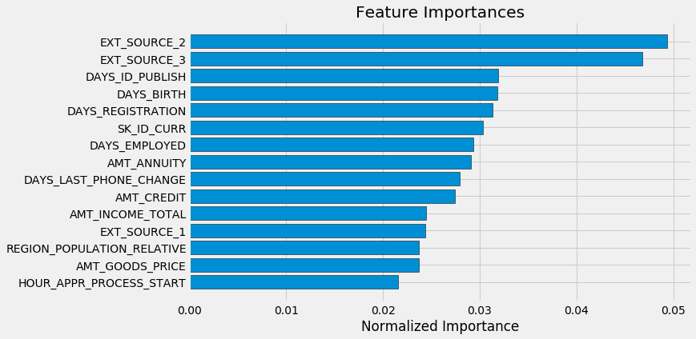

```python
feature_importances_sorted = plot_feature_importances(feature_importances)
```

-> 예상했던대로 모델에 가장 중요한 영향을 끼친 변수는 EXT_SOURCE와 DAYS_BIRTH 였습니다. 모델에 주 요인이 되는 몇 가지 변수가 있다는 것을 알 수 있으며, 이는 성능 저하 없이 많은 특징들을 떨어뜨릴 수 있음을 시사합니다. 변수 가져오기는 모형을 해석하거나 차수 축소를 수행하는 가장 정교한 방법은 아니지만, 모델이 예측을 할 때 어떤 요소를 고려하는지 이해하는데 도움이 됩니다.

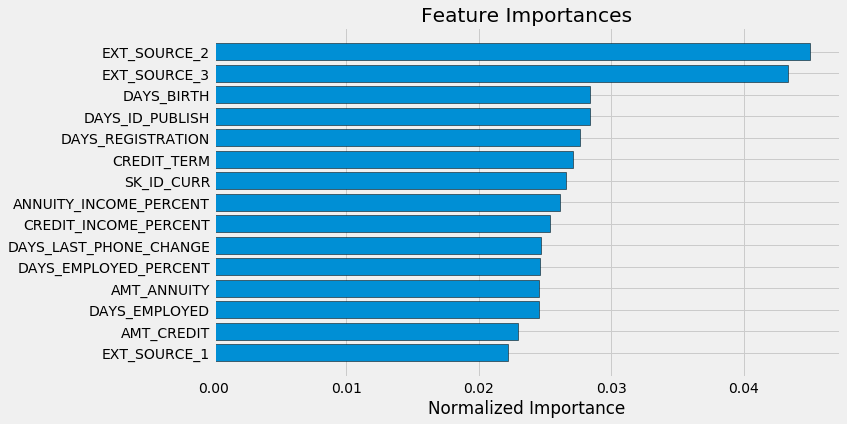

```python
feature_importances_domain_sorted = plot_feature_importances(feature_importances_domain)
```

-> 전처리 과정에서 도메인 지식과 관련된 변수(CREDIT_TERM, ANNUITY_INCOME_PERCENT,CREDIT_INCOME_PERCENT,DAYS_EMPLOYED_PERCENT)들 모두가 15위 안에 들어있는 것을 확인할 수가 있습니다.

# 7. 환경데이터로의 활용방안

```
주제: 가뭄정보분석시스템을 활용한 가뭄 위험지역 분류(예측) 모델링

배경: 가뭄은 물 공급이 부족한 시기를 일컫는 말로 일반적으로 평균이하의 강수량이 지속적으로 보이는 지역에서 나타납니다. 가뭄은 강수           등의 자연현상이나 인위적 행위에 의해 영향을 받는 물의 공급과 수요 간의 상호작용으로 발생하며 경제적, 환경적 그리고 개개인의           고통 등 사회에 많은 영향을 미칩니다. 이에 가뭄을 지역적 환경 데이터를 활용하여 사전에 예방하게 된다면 가뭄의 피해를 최소화하           는데 기여할 것입니다.

데이터(예상) : 한국수자원공사(K-Water)의 물종합정보처의 국가가뭄정보분석센터에서 운영하는 가뭄정보분석시스템 DB에 있는 데이터 중                      행정동코드, 가뭄판단 기준정보, 급수량, 기상청 자료 등 가뭄에 영향을 미칠 수 있다고 판단되는 데이터들을 활용합니다

분석 방향: 행정동(읍면동)을 대상으로 가뭄 위험판단(0:양호,관심,주의/1:경계,심각)을 종속변수(반응변수)로 설정하고 가뭄에 영향을 줄                수 있다고 볼 수 있는 여러 요인들(예: 급수량, 취수량, 일 강우량 등)을 독립변수(설명변수)로 설정하여 앞서 제시한 여러 분류모델들을 통해 가뭄 위험지역을 예측하는 모델링을 실시하고자 합니다.

결론 도출 및 활용방안: 우선 각 분류모델 중 가장 정확도가 높은 모델을 사용하고 해당 지역에 대해 사전에 가뭄 예상을 알리는 시스템을                            개발하고 동시에 가뭄 위험지역을 분류하는데 주요한 요인들을 파악하여 문제점을 해결할 수 있는 정보들을 제공하여 지자체를 비롯한 관련 부서에서 미리 가뭄 피해를 막을 수 있게끔 하는데 활용하고자 합니다.
```